## Factors Affecting Support for Autocratic Governance Among U.S. Adults

#### Sam Minard<sup>1</sup> & Efrain Ramirez<sup>2</sup>

<sup>*1*</sup>*Department of Social Sciences & Global Studies, California State University, Monterey Bay, Seaside, CA*

<sup>*2*</sup>*Department of Psychology, California State University, Monterey Bay, Seaside, CA*

## Introduction

As of 2021, 70% of the world’s population, or 5.4 billion people, live under an autocratic regime (Boese et al., 2022). Autocracies are a form of government “by a single person or small group that has unlimited power or authority” (Cambridge University Press & Assessment, n.d.), and they often arise from populist movements. Populism is an exclusionary, anti-elitist, anti-pluralist political ideology based on the idea that the “true people” are under threat from some kind of elite enemy, be it an economic, political, racial, or foreign one (Berlin et al., 1968). The ideology can fuel support for autocratic leaders who persuade the public that only they can protect them from perceived enemies, thus justifying the consolidation of executive power without accountability (Al Waroi et al., 2024; Baturo et al., 2024). Donald Trump’s populist messaging has galvanized many Americans against a variety of perceived enemies, including racial and gender minorities, immigrants, and other vaguely defined “elites.” Since regaining the presidency in 2025, Trump has taken steps to consolidate his power and remove checks and balances, thus bringing the United States closer to an authoritarian autocracy– and many Americans wholeheartedly support this transformation. Therefore, this paper seeks to understand the factors associated with support for autocratic leadership among Americans.

Populist movements and the autocratic leaders they support are often fueled by anxiety and subjective perceptions of economic insecurity, irrespective of whether objective measures of hardship are present (Gidron & Hall, 2017). In other words, actual economic insecurity is not necessary, only the perception of insecurity. Moreover, it is the perception of economic insecurity at the macro level that significantly predicts these attitudes, not at the micro level (Watson et al., 2021). Severe real-world threats can be especially impactful in this regard. For example, through their analysis of the Covid-19 pandemic and the subsequent economic downturn in Italy, Rocatto et al. (2020) found that times of uncertainty and hardship can drive people toward anti-democratic, authoritarian, and autocratic leaders because they offer a restored sense of control over their social world. Given that a recent Pew Research Center poll found Americans’ current economic ratings to be predominantly negative (Cerda, 2025), it is important to test the relationship between subjective economic insecurity and anti-democratic sentiment in the US. Therefore, our first research question is as follows: *How does perceived macro level economic insecurity relate to support for autocratic leadership?*

As the information channels American society relies on continue to evolve, it is important to consider the relationship between media type preferences and anti-democratic sentiments that encourage support for autocratic leadership. Notably, mainstream media trust among conservatives has declined, leading them to seek alternatives like social media, where they may encounter misinformation and populist rhetoric (Hutchens et al., 2025; Mourão, 2017). While social media has been touted as a democratic panacea because of its potential for disseminating anti-regime information and mobilizing collective action, many autocratic regimes engage in social media censorship (Gunitsky, 2015). However, Gunitsky (2015) argues that many regimes have since moved from suppression to co-optation of social media as a tool to maintain autocratic stability– a far more insidious tactic. Co-opting social media allows autocratic regimes to shape the discourse on social media, promote counter-mobilization, and bolster regime legitimacy. Given autocratic co-optation alongside the transition to social media as the public’s primary source of news and information, it is crucial to investigate the relationship between social media use and support for autocratic governance among American adults. Furthermore, the disparity in media preferences between conservatives and liberals means that political ideology must be considered as a mediating factor in this relationship. As a result, we propose the following research question: *Is a preference for getting news and information primarily from social media associated with support for autocratic leadership? How does this relationship vary depending on political ideology?*

By investigating these research questions, this paper will contribute to our understanding of the factors associated with support for autocratic leadership among Americans. First, we hypothesize that higher perceived macro level economic insecurity is associated with support for autocratic leadership. Second, we hypothesize that there is a stronger relationship between the preference for getting news and information primarily from social media and support for autocratic leadership among conservatives compared to liberals.

## Methods

### Variable Creation

The primary dependent variable in this study is support for autocratic leadership, which was measured through the following question: “Would each of the following political systems be a good or bad way of governing this country? A system in which a strong leader can make decisions without interference from Congress or the courts.” Response options included a range from “Very good” to “Very bad,” and “Refused.” This was re-coded into “Supports” and “Does not support” to ensure a binary response variable.

Independent variables we considered included demographics such as age, race, gender, and family income. In addition, we used economic perception (“How would you describe the current economic situation in the U.S.?”) to measure perceived economic insecurity at the macro level. Categories were collapsed into “Good” and “Bad.” Finally, multiple variables measured respondents’ news source and social media preferences, including how often respondents get news, facts, and opinions about issues or events from social media sites, and whether respondents prefer getting various kinds of information from news outlets, social media, both, or neither. The five variables concerning whether respondents preferred news outlets or social media were re-coded to contain three levels (2: “Prefers social media”; 1: “Prefers both”; and 0: “Prefers news outlets or neither”). Then, the values for each were summed within each row to assign an index score for social media preference to each respondent. With a range of 0-10, higher scores indicated a stronger preference for obtaining information from social media. For all variables, “Refused” responses were treated as “NA” and dropped.

## Results

### Exploratory Data Analysis

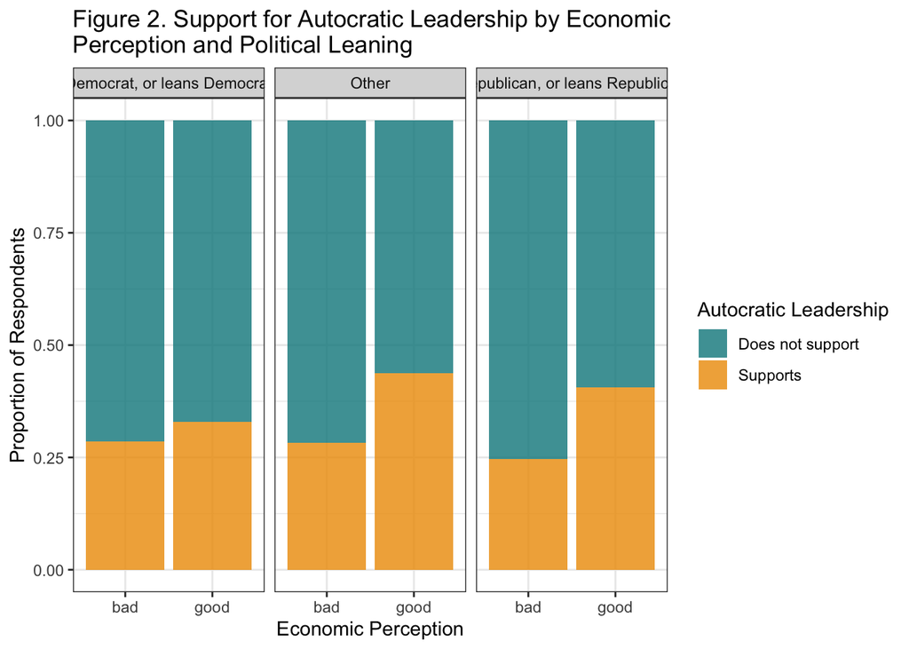

### Statistical Analysis

Log odds model: $ln(p(x)/1-p(x))=-0.57324+0.04294x_{1}+0.02412x_{2}+0.44557x_{3}-0.02921x_{4}+0.22214x_{5}-0.58883x_{6}-0.06985x_{7}+0.42960x_{8}-0.69719x_{9}+-1.26958x_{10}+0.04836x_{7}x_{1}-0.08469x_{11}x_{1}$

## Appendix

x <categorical>

| val | label | frq | raw.prc | valid.prc | cum.prc |  |
| --- | --- | --- | --- | --- | --- | --- |
| very good |  | 67 | 1.91 | 1.91 | 1.91 |  |
| somewhat good |  | 1012 | 28.77 | 28.77 | 30.68 |  |
| somewhat bad |  | 1639 | 46.60 | 46.60 | 77.28 |  |
| very bad |  | 799 | 22.72 | 22.72 | 100.00 |  |
| NA | NA | 0 | 0.00 | NA | NA |  |
| total N=3517 · valid N=3517 · x̄=2.90 · σ=0.76 |  |  |  |  |  |  |

```r
#these can be moved into the appropriate places in the paper later
```

Table 1. Frequency table for age categories.

```
## x <categorical>
## # total N=2065 valid N=2065 mean=2.41 sd=0.97
##
## Value |   N | Raw % | Valid % | Cum. %
## --------------------------------------
## 18-29 | 370 | 17.92 |   17.92 |  17.92
## 30-49 | 826 | 40.00 |   40.00 |  57.92
## 50-64 | 524 | 25.38 |   25.38 |  83.29
## 65+   | 345 | 16.71 |   16.71 | 100.00
## <NA>  |   0 |  0.00 |    <NA> |   <NA>
```

Table 2. Frequency table for income categories.

```
## x <categorical>
## # total N=2065 valid N=2065 mean=1.89 sd=0.70
##
## Value         |    N | Raw % | Valid % | Cum. %
## -----------------------------------------------
## Lower income  |  632 | 30.61 |   30.61 |  30.61
## Middle income | 1028 | 49.78 |   49.78 |  80.39
## Upper income  |  405 | 19.61 |   19.61 | 100.00
## <NA>          |    0 |  0.00 |    <NA> |   <NA>
```

Table 3. Frequency table for race categories.

```
## x <categorical>
## # total N=2065 valid N=2065 mean=1.55 sd=0.50
##
## Value     |    N | Raw % | Valid % | Cum. %
## -------------------------------------------
## Non-White |  935 | 45.28 |   45.28 |  45.28
## White     | 1130 | 54.72 |   54.72 | 100.00
## <NA>      |    0 |  0.00 |    <NA> |   <NA>
```

Table 4. Frequency table for economic perception categories.

```
## x <categorical>
## # total N=2065 valid N=2065 mean=1.71 sd=0.46
##
## Value |    N | Raw % | Valid % | Cum. %
## ---------------------------------------
## good  |  607 | 29.39 |   29.39 |  29.39
## bad   | 1458 | 70.61 |   70.61 | 100.00
## <NA>  |    0 |  0.00 |    <NA> |   <NA>
```

Table 5. Frequency table for political leaning categories.

```
## x <categorical>
## # total N=2065 valid N=2065 mean=1.48 sd=0.56
##
## Value                           |    N | Raw % | Valid % | Cum. %
## -----------------------------------------------------------------
## Democrat, or leans Democrat     | 1152 | 55.79 |   55.79 |  55.79
## Republican, or leans Republican |  844 | 40.87 |   40.87 |  96.66
## Other                           |   69 |  3.34 |    3.34 | 100.00
## <NA>                            |    0 |  0.00 |    <NA> |   <NA>
```

## References

Al Waroi, M. N. A. L., Riyanta, S., & Rustam, M. R. (2024). Populism and the erosion of democratic checks and balances: A systematic literature review across regions. International Journal of Multidisciplinary Research and Analysis, 7(10), 4728-4738. https://doi.org/10.47191/ijmra/v7-i10-18

Baturo, A., Kenny, P. D., & Balta, E. (2024). Leaders’ experience and the transition from populism to dictatorship. Democratization, 1–24. https://doi.org/10.1080/13510347.2024.2391482

Berlin, I., Hofstadter, R., MacRae, D., Schapiro, L., Seton-Watson, H., Touraine, A., Venturi, F., Walicki, A., & Worsley, P. (1968). To define populism. Government and Opposition, 3(2), 137–179. http://www.jstor.org/stable/44481863

Boese, V. A., Lundstedt, M., Morrison, K., Sato, Y., & Lindberg, S. I. (2022). State of the world 2021: Autocratization changing its nature? Democratization, 29(6), 983–1013. https://doi.org/10.1080/13510347.2022.2069751

Cambridge University Press & Assessment. (n.d.). Autocracy. In Cambridge dictionary. Retrieved March 16, 2025, from https://dictionary.cambridge.org/us/dictionary/english/autocracy

Cerda, A. (2025, February 11). Republicans think economy will improve over the next year, Democrats expect it to get worse. Pew Research Center. https://www.pewresearch.org/short-reads/2025/02/11/republicans-think-economy-will-improve-over-the-next-year-democrats-expect-it-to-get-worse/

Gidron, N., & Hall, P. A. (2017). The politics of social status: Economic and cultural roots of the populist right. The British Journal of Sociology, 68(S1). https://doi.org/10.1111/1468-4446.12319

Hutchens, M. J., Shaughnessy, B., & DuBosar, E. (2025). Populist hyperpartisans?: The interaction between partisan media exposure and populism in the 2020 US presidential election. Mass Communication and Society, 28(1), 51–75. https://doi.org/10.1080/15205436.2023.2264265

Mourão, R. R., Thorson, E., Chen, W., & Tham, S. M. (2018). Media repertoires and news trust during the early Trump administration. Journalism Studies, 19(13), 1945–1956. https://doi.org/10.1080/1461670X.2018.1500492

Mutz, D. C. (2018). Status threat, not economic hardship, explains the 2016 presidential vote. Proceedings of the National Academy of Sciences, 115(19). https://doi.org/10.1073/pnas.1718155115

Pew Research Center. (2023). American Trends Panel Wave 124 [Data file and codebook]. Retrieved from https://www.pewresearch.org/dataset/american-trends-panel-wave-124/.

Roccato, M., Cavazza, N., Colloca, P., & Russo, S. (2020). A democratic emergency after a health emergency? Exposure to COVID‐19, perceived economic threat and support for anti‐democratic political systems. Social Science Quarterly, 101(6), 2193–2202. https://doi.org/10.1111/ssqu.12865

Wahba, L. L. (2022). Innocents, psychopaths and the imagination. Journal of Analytical Psychology, 67(1), 183–195. https://doi.org/10.1111/1468-5922.12773

Watson, B., Law, S., & Osberg, L. (2022). Are populists insecure about themselves or about their country? Political attitudes and economic perceptions. Social Indicators Research, 159(2), 667–705. https://doi.org/10.1007/s11205-021-02767-8